# Cap-Dap

Anna

11/8/2022

# Introduction

I have been collecting zooplankton (*Aglaodiaptomus leptopus*) from a bog in Sevey’s Point and in the lab I anesthetize and photograph them under a microscope. I then import those photos into Photoshop and take an average of the total body color of each specimen. I record the color values **L**, **a**, and **b** (variables in my data sheet) which represent luminosity, the red vs. green scale, and the blue vs. yellow scale, respectively. After recording these initial values, I leave the zoopl. under different light treatments for 7 days and record how their pigment color changes over the course of the week. Under my “treatment” variable in my data you will see the values `D` and `NL` which represent darkness and natural light treatments, respectively. For my project, I would like to create statistical models showing if these three color elements of the zoopl. pigment change significantly over the course of the week, and if different light treatments produce significantly different results.

# Preliminary steps

Setting things up:

```r
rm(list=ls())
library(here)
library(tidyverse)
library(ggfortify)
```

Import the data

```r
DF <- read.csv(here("Data", "biostats_copepod_data.csv"))
```

Before importing my data, I ensured that it was “tidy” by appropriately naming column headers without spaces or special characters. For the variables I am interested in working with, I organized the data so that there is only one variable per cell.

Please see the metadata in the `Data` folder of this project for explanation of the variables included in the data.

I need to convert treatment and before_after from character data to factor data:

```r
DF$treatment <- as.factor(DF$treatment)
DF$before_after <- as.factor(DF$before_after)

levels(DF$treatment)
levels(DF$before_after)
```

Since there are only 2 levels in each variable, I don’t need to revel them.

# Analysis

For looking at the data, I will be following this workflow:

`Plot > Guess relationships > Create model > Guess model assumptions > Run/interpret model > Replot to show key relationships`

#### Looking at the data for luminosity:

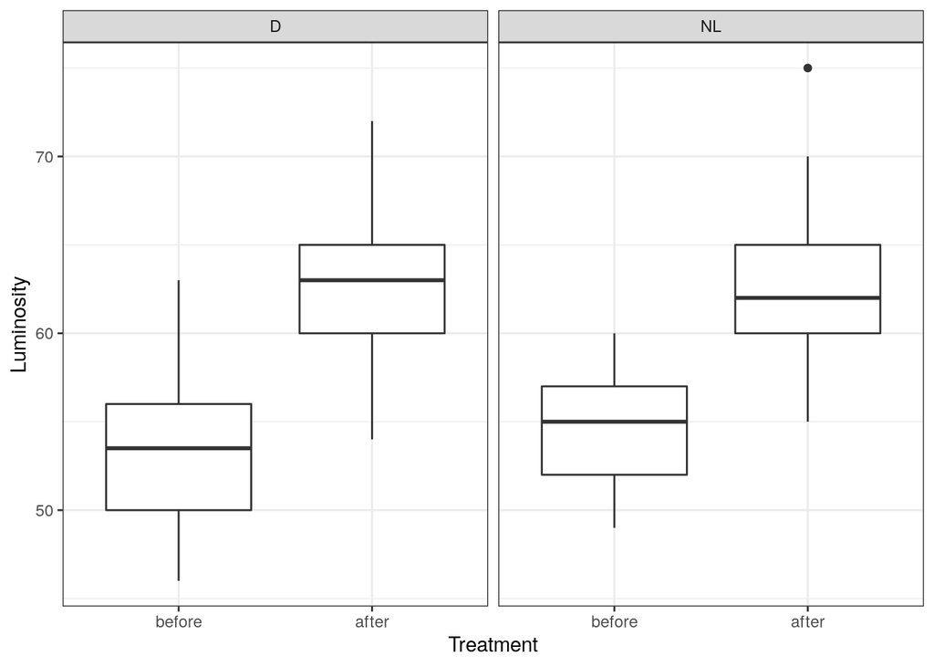

```r
ggplot(DF, aes(x = before_after, y = L)) +
geom_boxplot() +
xlab("Treatment") +
ylab("Luminosity") +
theme_bw() +
facet_wrap(~treatment) +
scale_x_discrete(limits = c("before", "after"))
```

Based on this plot, I make an assumption that luminosity increases significantly after the copepods have been in natural light and darkness treatments for 7 days. In other words, their pigment fades under these light treatments.

Now, let’s create a stats model to take a closer look at the relationship:

```r
t.test(L ~ before_after, data = DF)
```

```
##
##  Welch Two Sample t-test
##
## data:  L by before_after
## t = 12.001, df = 66.378, p-value < 2.2e-16
## alternative hypothesis: true difference in means between group after and group before is not equal to 0
## 95 percent confidence interval:
##  7.061627 9.879677
## sample estimates:
##  mean in group after mean in group before
##             62.49565             54.02500
```

This does not separate the different light treatments, but shows that for both natural light and darkness treatments, the pigmentation of the copepods fades during a 7-day period.

The p-value from this test is <0.05, so we reject the null hypothesis that there is no significant difference in the luminosity value between the before and after groups for natural light and darkness treatments.

While this is helpful to see, I want to answer the question **Does the effect of the before and after measurements on L depend on what kind of light treatment the copepods were exposed to?** I will do that by running a generalized linear model.

I need to use glm with poisson as the family because L is not on a continuous scale.

```r
model_L <- glm(L ~ treatment * before_after, data = DF, family = poisson)
```

Now to check assumptions:

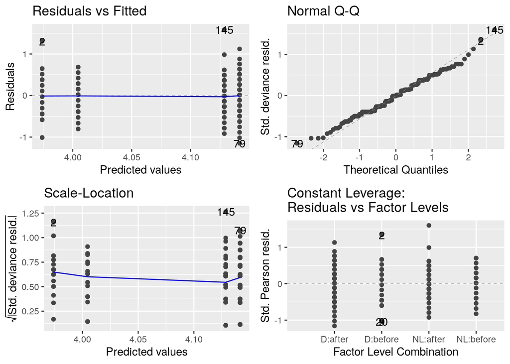

```r
autoplot(model_L, smooth.color = NA)
```

Residuals and distribution look good, so we can move on to looking at the model.

Now I will look at the model

```r
anova(model_L)
```

```
## Analysis of Deviance Table
##
## Model: poisson, link: log
##
## Response: L
##
## Terms added sequentially (first to last)
##
##
##                        Df Deviance Resid. Df Resid. Dev
## NULL                                     154     72.726
## treatment               1    0.026       153     72.700
## before_after            1   36.154       152     36.546
## treatment:before_after  1    0.785       151     35.761
```

…and look at the summary

```r
summary(model_L)
```

```
##
## Call:
## glm(formula = L ~ treatment * before_after, family = poisson,
##     data = DF)
##
## Deviance Residuals:
##      Min        1Q    Median        3Q       Max
## -1.14992  -0.37816  -0.01114   0.36676   1.58632
##
## Coefficients:
##                                Estimate Std. Error z value Pr(>|z|)
## (Intercept)                     4.14149    0.01656 250.141  < 2e-16 ***
## treatmentNL                    -0.01294    0.02359  -0.549    0.583
## before_afterbefore             -0.16743    0.03484  -4.805 1.54e-06 ***
## treatmentNL:before_afterbefore  0.04349    0.04907   0.886    0.376
## ---
## Signif. codes:  0 '***' 0.001 '**' 0.01 '*' 0.05 '.' 0.1 ' ' 1
##
## (Dispersion parameter for poisson family taken to be 1)
##
##     Null deviance: 72.726  on 154  degrees of freedom
## Residual deviance: 35.761  on 151  degrees of freedom
## AIC: 963.87
##
## Number of Fisher Scoring iterations: 3
```

By looking at this output, I can see that there is significant difference between before and after luminosity results, but the light treatments themselves did not affect luminosity differently.

First I need to get the means to compare, so I have to use group by and summarize:

```r
sumDF_L <- DF %>%
  group_by(treatment, before_after) %>%
  summarize(meanL = mean(L))
```

This is what that interaction plot looks like:

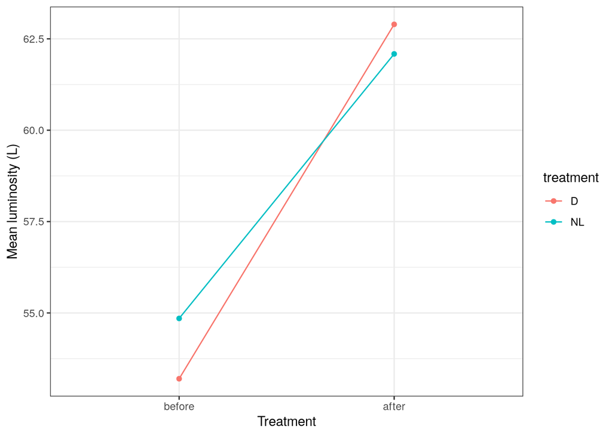

```r
ggplot(sumDF_L, aes(before_after, meanL, color = treatment, group = treatment)) +
  geom_point() +
  geom_line() +
  theme_bw() +
  scale_x_discrete(limits = c("before", "after")) +
  xlab("Treatment") +
  ylab("Mean luminosity (L)")
```

This plot shows the relationship that for both darkness (D) and natural light (NL) treatments, the mean luminosity value after the 7-day trial is significantly different than the initial luminosity value. In summary, both treatments caused the copepod pigmentation to fade and become more luminous. Despite the fact that the lines interact, this plot shows that the slopes of lines are not dramatically different, which is why I concluded that the different treatments themselves did not affect luminosity differently.

#### Looking at the a-value

As a quick recap, the a-value represents the red-green color scale when measuring color. The red pigment is significant for this study because the copepods typically present more red pigmentation in the Spring and Fall seasons.

Following the data workflow, I will first make a simple plot to look at the general trend of the data.

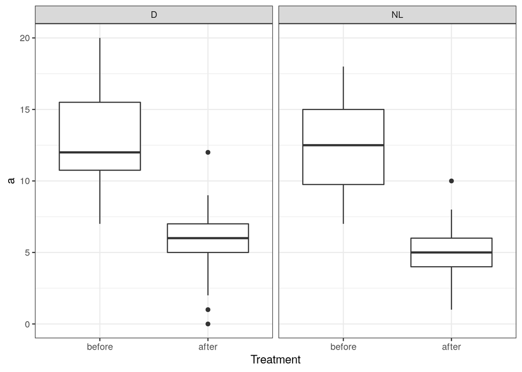

```r
ggplot(DF, aes(x = before_after, y = a)) +
geom_boxplot() +
xlab("Treatment") +
ylab("a") +
theme_bw() +
facet_wrap(~treatment)+
scale_x_discrete(limits = c("before", "after"))
```

Looking at this plot, it appears that in both the darkness and natural light treatments, the copepods lose red pigment over the course of the 7-day trial.

To check this assumption, I will run a similar model to the test I ran for luminosity:

```r
model_a <- glm(a ~ treatment * before_after, data = DF, family = poisson)
```

I am choosing the poisson distribution again because the a-scale is not continuous.

I will then check the assumptions I made for this test

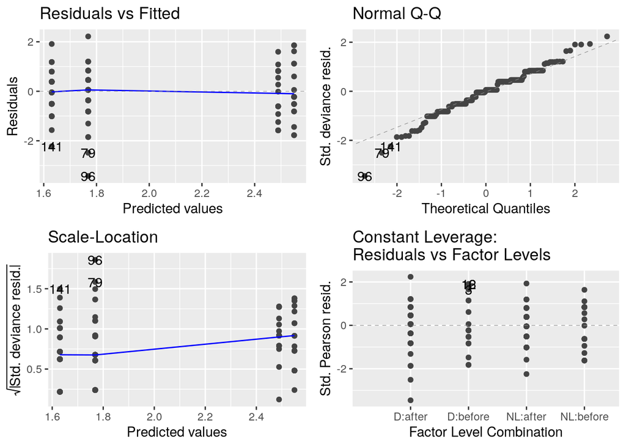

```r
autoplot(model_a, smooth.color = NA)
```

The residuals look evenly distributed and the distribution follows a generally normal trend, so I can continue now to modelling the data

```r
anova(model_a)
```

```
## Analysis of Deviance Table
##
## Model: poisson, link: log
##
## Response: a
##
## Terms added sequentially (first to last)
##
##
##                        Df Deviance Resid. Df Resid. Dev
## NULL                                     154     299.41
## treatment               1    2.854       153     296.55
## before_after            1  175.516       152     121.04
## treatment:before_after  1    0.420       151     120.62
```

… and looking at the summary stats

```r
summary(model_a)
```

```
##
## Call:
## glm(formula = a ~ treatment * before_after, family = poisson,
##     data = DF)
##
## Deviance Residuals:
##     Min       1Q   Median       3Q      Max
## -3.4241  -0.5086   0.0558   0.4559   2.2176
##
## Coefficients:
##                                Estimate Std. Error z value Pr(>|z|)
## (Intercept)                     1.76850    0.05423  32.610   <2e-16 ***
## treatmentNL                    -0.13823    0.07986  -1.731   0.0835 .
## before_afterbefore              0.78094    0.08275   9.437   <2e-16 ***
## treatmentNL:before_afterbefore  0.07785    0.12014   0.648   0.5170
## ---
## Signif. codes:  0 '***' 0.001 '**' 0.01 '*' 0.05 '.' 0.1 ' ' 1
##
## (Dispersion parameter for poisson family taken to be 1)
##
##     Null deviance: 299.41  on 154  degrees of freedom
## Residual deviance: 120.62  on 151  degrees of freedom
## AIC: 702.96
##
## Number of Fisher Scoring iterations: 4
```

This output shows that there is significant difference in the a-value before and after the copepods are exposed to the light treatments, but the light treatments themselves did not affect a-value differently.

To plot this finding, I will create an interaction plot. First, I find the means of the a values to compare…

```r
sumDF_a <- DF %>%
  group_by(treatment, before_after) %>%
  summarize(mean_a = mean(a))
```

… and then I can create the interaction plot.

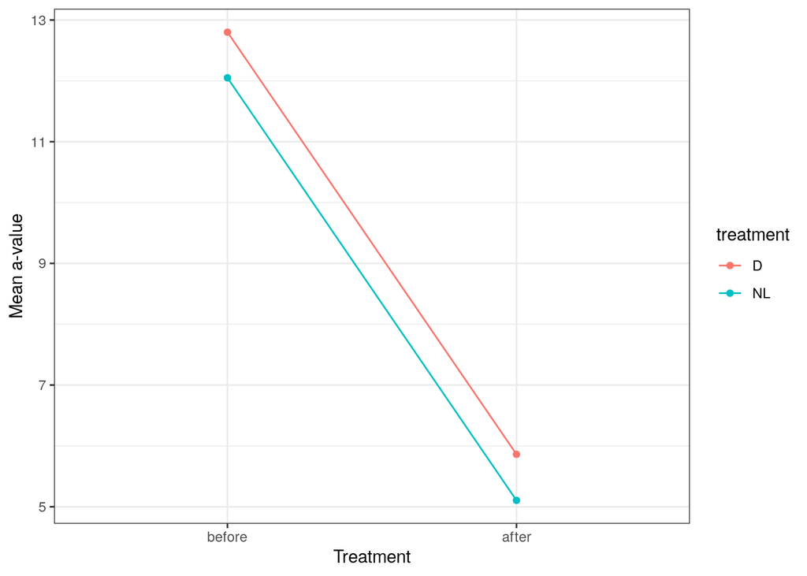

```r
ggplot(sumDF_a, aes(before_after, mean_a, color = treatment, group = treatment)) +
  geom_point() +
  geom_line() +
  theme_bw() +
  scale_x_discrete(limits = c("before", "after")) +
  xlab("Treatment") +
  ylab("Mean a-value")
```

This plot shows that the lines for the two light treatments do not interact. It also shows that for both light treatments, the copepods lose a significant amount of their red pigment.

#### Looking at the b-value

Looking at the b-value for the copepod pigment is a very similar process as looking at the a-value. The b-value is the blue-yellow scale for color, so let’s take a look at this data.

To begin, I will make a quick plot to visualize the data:

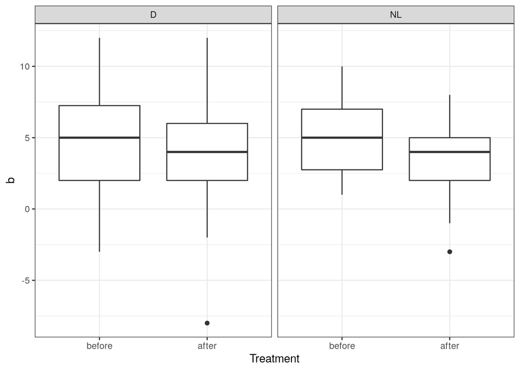

```r
ggplot(DF, aes(x = before_after, y = b)) +
geom_boxplot() +
xlab("Treatment") +
ylab("b") +
theme_bw() +
facet_wrap(~treatment)+
scale_x_discrete(limits = c("before", "after"))
```

Just by looking at these figures, it appears to me that the mean b-value for both light treatments does not change significantly after the 7-day trial period. But to be certain of this, I need to create a model of the data.

I’m going to run a generalized linear model to look at this.

```r
model_b <- glm(b ~ treatment * before_after, data = DF, family = gaussian)
```

I cannot use a poisson distribution for this model because it does not allow for negative values. Now I need to check the assumptions of this model before running any tests:

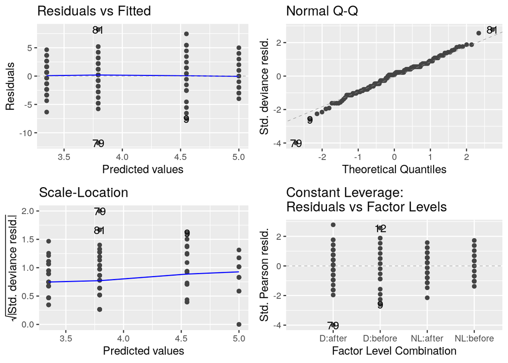

```r
autoplot(model_b, smooth.color = NA)
```

The residuals and distribution confirm my assumptions, so I can move onto running the stats.

```r
anova(model_b)
```

```
## Analysis of Deviance Table
##
## Model: gaussian, link: identity
##
## Response: b
##
## Terms added sequentially (first to last)
##
##
##                        Df Deviance Resid. Df Resid. Dev
## NULL                                     154     1389.9
## treatment               1    1.676       153     1388.2
## before_after            1   42.878       152     1345.4
## treatment:before_after  1    5.906       151     1339.5
```

```r
summary(model_b)
```

```
##
## Call:
## glm(formula = b ~ treatment * before_after, family = gaussian,
##     data = DF)
##
## Deviance Residuals:
##      Min        1Q    Median        3Q       Max
## -11.7931   -1.8966    0.2069    1.6491    8.2069
##
## Coefficients:
##                                Estimate Std. Error t value Pr(>|t|)
## (Intercept)                      3.7931     0.3911   9.699   <2e-16 ***
## treatmentNL                     -0.4422     0.5555  -0.796    0.427
## before_afterbefore               0.7569     0.7723   0.980    0.329
## treatmentNL:before_afterbefore   0.8922     1.0934   0.816    0.416
## ---
## Signif. codes:  0 '***' 0.001 '**' 0.01 '*' 0.05 '.' 0.1 ' ' 1
##
## (Dispersion parameter for gaussian family taken to be 8.870528)
##
##     Null deviance: 1389.9  on 154  degrees of freedom
## Residual deviance: 1339.4  on 151  degrees of freedom
## AIC: 784.14
##
## Number of Fisher Scoring iterations: 2
```

I can see from this output that the p-values for both the before and after data as well as the interaction between the light treatments are all greater than 0.05, showing no significant difference for either of these comparisons. In summary, the b-value did not change significantly over the course of 7 days for either the natural light or darkness treatments.

I am going to plot these findings using a generalized linear model comparing the means

```r
sumDF_b <- DF %>%
  group_by(treatment, before_after) %>%
  summarize(mean_b = mean(b))
```

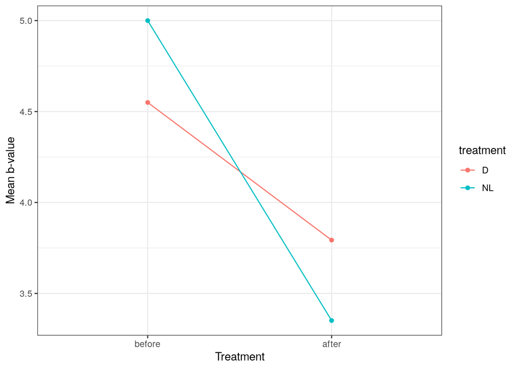

```r
ggplot(sumDF_b, aes(before_after, mean_b, color = treatment, group = treatment)) +
  geom_point() +
  geom_line() +
  theme_bw() +
  scale_x_discrete(limits = c("before", "after")) +
  xlab("Treatment") +
  ylab("Mean b-value")
```

Although it appears that the lines interact, the mean b-values before and after the light treatment exposures were not significantly different, so therefore we cannot conclude that natural light and darkness treatments affected the b-value differently.